# Wybór modelu

Przemyslaw Biecek

Modele liniowe i mieszane

Na podstawie rozdziału 2.6

# Kryteria i błędy

!!! Błędy typu I i II - klasyka.

!!! Błędy typu M i S podane przez Andrew Gelman.

Kryteria wyboru modelu:

- GIC
- R^2
- Adjusted R^2
- Cp Mallowsa
- Walidacja krzyżowa

## Przykład zabawka

Związek stężenia elastazy a pracą nerki (GFR). Mamy dane o sprawności przeszczepionej nerki dla 54 pacjentów.

Interesuje nas określenie, które zmienne (wiek, płeć, waga, elastaza) mają związek z GFR.

```r
library(PBImisc)
library(car)

head(elastase)
```

```
##   sex age weight elastase    GFR
## 1   0  53     64      311 43.022
## 2   0  40     50      314 49.128
## 3   0  52     56      736 60.172
## 4   0  53     68      325 36.950
## 5   0  41     61      526 36.852
## 6   0  55     64      460 57.220
```

```r
summary(lm(GFR~weight+poly(elastase,3), data=elastase))
```

```
##
## Call:
## lm(formula = GFR ~ weight + poly(elastase, 3), data = elastase)
##
## Residuals:
##     Min      1Q  Median      3Q     Max
## -29.326  -9.670  -1.292  12.029  27.930
##
## Coefficients:
##                    Estimate Std. Error t value Pr(>|t|)
## (Intercept)         78.5673    12.4687   6.301 8.02e-08 ***
## weight              -0.5330     0.1742  -3.060  0.00358 **
## poly(elastase, 3)1  37.5072    14.5685   2.575  0.01311 *
## poly(elastase, 3)2  45.3930    14.5790   3.114  0.00308 **
## poly(elastase, 3)3  18.1676    14.4692   1.256  0.21521
## ---
## Signif. codes:  0 '***' 0.001 '**' 0.01 '*' 0.05 '.' 0.1 ' ' 1
##
## Residual standard error: 14.47 on 49 degrees of freedom
## Multiple R-squared:  0.3566, Adjusted R-squared:  0.3041
## F-statistic: 6.789 on 4 and 49 DF,  p-value: 0.0001978
```

## Przykład symulacyjny

```r
 set.seed(4)
 y = rnorm(100)
 X = matrix(rnorm(9800),100,98)
 summary(lm(y~X))
```

```
##
## Call:
## lm(formula = y ~ X)
##
## Residuals:
##          1          2          3          4          5          6
## -0.1535521  0.2832009  0.0078614  0.2422542  0.1319971  0.3091550
##          7          8          9         10         11         12
##  0.2562930 -0.0165134 -0.2753093  0.0210014  0.0254418 -0.2144930
##         13         14         15         16         17         18
## -0.0780485 -0.1246110  0.1430434 -0.0884006 -0.0753817  0.0704321
##         19         20         21         22         23         24
## -0.0942845 -0.3913493 -0.0411945 -0.0648590  0.0915896 -0.0317637
##         25         26         27         28         29         30
##  0.1009021  0.0288946  0.2133880  0.2609053  0.1899077  0.0314786
##         31         32         33         34         35         36
## -0.1445401  0.2803142 -0.2536712 -0.0002138 -0.2388481  0.2881445
##         37         38         39         40         41         42
##  0.0432571  0.0848170 -0.1457812  0.1072985  0.0423907 -0.0035420
##         43         44         45         46         47         48
##  0.0436506 -0.1503806  0.0456718 -0.1374190 -0.2950960 -0.1159417
##         49         50         51         52         53         54
##  0.0935159  0.1099119  0.2171129 -0.0316657  0.0054261  0.0049564
##         55         56         57         58         59         60
## -0.0329504  0.1429399 -0.2217728  0.1328027 -0.0696384 -0.1338857
##         61         62         63         64         65         66
## -0.3300658 -0.1144236 -0.1808929  0.2282928 -0.0144371 -0.0198731
##         67         68         69         70         71         72
## -0.1797091  0.1690063 -0.1430170  0.0502093  0.1339113 -0.2497255
##         73         74         75         76         77         78
##  0.1425264  0.0959847  0.1250954 -0.1200751  0.1761902 -0.0591108
##         79         80         81         82         83         84
##  0.0629222  0.1424517 -0.1679605 -0.0793452  0.1586128  0.0443185
##         85         86         87         88         89         90
## -0.2437515  0.0793538 -0.2006996 -0.1475627  0.0829693 -0.0167630
##         91         92         93         94         95         96
## -0.0808951 -0.1113697  0.0829387  0.1696173  0.0331986  0.1122999
##         97         98         99        100
##  0.1524163  0.1328613 -0.0070089 -0.3333395
##
```

[output cut: 90 more lines]

```
## X88          0.7907819  2.4461878   0.323    0.801
## X89         -0.6730363  1.4688119  -0.458    0.726
## X90          1.2676962  3.7949614   0.334    0.795
## X91         -0.0824692  1.5341454  -0.054    0.966
## X92          0.8069590  1.1440392   0.705    0.609
## X93         -0.9766957  2.4620868  -0.397    0.760
## X94         -0.1350569  0.6377033  -0.212    0.867
## X95          0.0894137  1.4191138   0.063    0.960
## X96         -0.1186764  1.0533921  -0.113    0.929
## X97          0.0540762  0.9080930   0.060    0.962
## X98         -0.7635469  1.0643809  -0.717    0.604
##
## Residual standard error: 1.563 on 1 degrees of freedom
## Multiple R-squared:  0.9704, Adjusted R-squared:  -1.927
## F-statistic: 0.3349 on 98 and 1 DF,  p-value: 0.9128
```

```r
 set.seed(1313)
 y = rnorm(100)
 X = matrix(rnorm(9800),100,98)
 # summary(lm(y~X))
```

Rozkład adjusted R^2 dla rosnącego p.

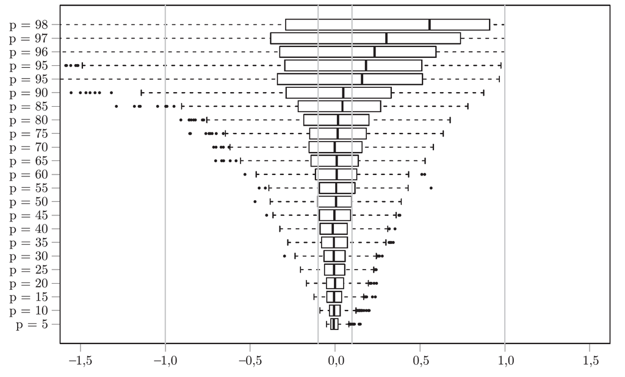

# Współliniowość zmiennych

```r
 vif(lm(GFR~., data=elastase))
```

```
##      sex      age   weight elastase
## 1.531081 1.244410 1.772674 1.025643
```

Testy typu I i III, brzegowe i sekwencyjne.

```r
 summary(model.el.1 <- lm(GFR~., data=elastase))
```

```
##
## Call:
## lm(formula = GFR ~ ., data = elastase)
##
## Residuals:
##     Min      1Q  Median      3Q     Max
## -34.359 -12.550  -0.127  11.688  37.229
##
## Coefficients:
##             Estimate Std. Error t value Pr(>|t|)
## (Intercept) 63.58907   16.29138   3.903  0.00029 ***
## sex          5.35466    5.59840   0.956  0.34353
## age          0.12816    0.21518   0.596  0.55419
## weight      -0.62831    0.25081  -2.505  0.01562 *
## elastase     0.02998    0.01314   2.281  0.02692 *
## ---
## Signif. codes:  0 '***' 0.001 '**' 0.01 '*' 0.05 '.' 0.1 ' ' 1
##
## Residual standard error: 15.88 on 49 degrees of freedom
## Multiple R-squared:  0.2251, Adjusted R-squared:  0.1618
## F-statistic: 3.558 on 4 and 49 DF,  p-value: 0.01261
```

```r
 summary(model.el.2 <- lm(GFR~weight+elastase, data=elastase))
```

```
##
## Call:
## lm(formula = GFR ~ weight + elastase, data = elastase)
##
## Residuals:
##     Min      1Q  Median      3Q     Max
## -34.303 -13.148  -0.982  11.311  38.497
##
## Coefficients:
##             Estimate Std. Error t value Pr(>|t|)
## (Intercept) 60.84222   15.00979   4.054 0.000173 ***
## weight      -0.46280    0.18786  -2.464 0.017172 *
## elastase     0.03122    0.01294   2.412 0.019483 *
## ---
## Signif. codes:  0 '***' 0.001 '**' 0.01 '*' 0.05 '.' 0.1 ' ' 1
##
## Residual standard error: 15.73 on 51 degrees of freedom
## Multiple R-squared:  0.2088, Adjusted R-squared:  0.1778
## F-statistic: 6.729 on 2 and 51 DF,  p-value: 0.00255
```

```r
 anova(model.el.2, model.el.1)
```

```
## Analysis of Variance Table
##
## Model 1: GFR ~ weight + elastase
## Model 2: GFR ~ sex + age + weight + elastase
##   Res.Df   RSS Df Sum of Sq      F Pr(>F)
## 1     51 12612
## 2     49 12352  2    259.69 0.5151 0.6007
```

Funkcja krokowego wyboru modelu.

```r
 model.el.3 = step(model.el.1)
```

```
## Start:  AIC=303.36
## GFR ~ sex + age + weight + elastase
##
##            Df Sum of Sq   RSS    AIC
## - age       1     89.43 12442 301.75
## - sex       1    230.62 12583 302.36
## <none>                  12352 303.36
## - elastase  1   1311.83 13664 306.81
## - weight    1   1581.98 13934 307.87
##
## Step:  AIC=301.75
## GFR ~ sex + weight + elastase
##
##            Df Sum of Sq   RSS    AIC
## - sex       1    170.27 12612 300.49
## <none>                  12442 301.75
## - elastase  1   1393.49 13835 305.48
## - weight    1   1573.78 14016 306.18
##
## Step:  AIC=300.49
## GFR ~ weight + elastase
##
##            Df Sum of Sq   RSS    AIC
## <none>                  12612 300.49
## - elastase  1    1439.2 14051 304.32
## - weight    1    1500.8 14113 304.56
```

```r
 summary(model.el.2)
```

```
##
## Call:
## lm(formula = GFR ~ weight + elastase, data = elastase)
##
## Residuals:
##     Min      1Q  Median      3Q     Max
## -34.303 -13.148  -0.982  11.311  38.497
##
## Coefficients:
##             Estimate Std. Error t value Pr(>|t|)
## (Intercept) 60.84222   15.00979   4.054 0.000173 ***
## weight      -0.46280    0.18786  -2.464 0.017172 *
## elastase     0.03122    0.01294   2.412 0.019483 *
## ---
## Signif. codes:  0 '***' 0.001 '**' 0.01 '*' 0.05 '.' 0.1 ' ' 1
##
## Residual standard error: 15.73 on 51 degrees of freedom
## Multiple R-squared:  0.2088, Adjusted R-squared:  0.1778
## F-statistic: 6.729 on 2 and 51 DF,  p-value: 0.00255
```

## Większy przykład

Usuwamy wiersze z brakami w danych i dodajemy zmienne pozwalające na konstrukcję krzywej sklejanej na podstawie roku budowy

```r
 apartments2 = na.omit(apartments[,c(13,1,3,5,7,8,9,10,14,15,16)])
 apartments2$construction1990 = apartments2$construction.date - 1990
 apartments2$starszy1990 = apartments2$construction.date > 1990
```

Dodajemy informację o odległości od centrum

```r
 centrumWsp = apartments2[apartments2$district=="Srodmiescie",10:11][1,]
 dzielnice = levels(apartments2$district)

 getDistKm <- function(x, y) {
   sqrt(sum(((x-y)*c(100,70))^2))
 }

 odl = sapply(dzielnice, function(x)
      getDistKm(centrumWsp, apartments2[apartments2$district == x, 10:11][1,]))
 apartments2$odleglosc = odl[apartments2$district]
 head(apartments2)
```

```
##   m2.price year surface    district n.rooms floor construction.date
## 1    10500 2008      20 Srodmiescie       1     7              1970
## 2     7000 2008      25    Pruszkow       1     1              1965
## 3     8384 2008      26     Bielany       1     6              1964
## 4     8518 2008      27        Wola       1     1              1962
## 5     8750 2008      28     Mokotow       1     1              1950
## 6     8750 2008      28     Mokotow       2     4              1968
##           type  condition      lat      lon construction1990 starszy1990
## 1   hipoteczne do remontu 52.22947 21.00761              -20       FALSE
## 2 spoldzielcze do remontu 52.17162 20.80639              -25       FALSE
## 3   hipoteczne do remontu 52.27114 20.95003              -26       FALSE
## 4 spoldzielcze      dobry 52.24238 20.98659              -28       FALSE
## 5   hipoteczne do remontu 52.19814 21.01752              -40       FALSE
## 6 spoldzielcze      dobry 52.19814 21.01752              -22       FALSE
##   odleglosc
## 1  0.000000
## 2 15.227681
## 3  5.797603
## 4  1.957446
## 5  3.209447
## 6  3.209447
```

Lista kandydujących zmiennych objaśniających, w modelowaniu prawdziwych danych często rozpatruje się wtórne zmienne wyznaczone jako przekształcenia wielomianowe lub interakcje zmiennych oryginalnych.

```r
 zm = c("factor(year)", "surface", "poly(surface,3)", "district", "n.rooms ", "floor", "type", "construction1990", "construction1990:starszy1990", "odleglosc", "poly(odleglosc,3)", "district:factor(year)", "district:type", "district:condition", "district:surface")

 # indeksy wszystkich podzbiorów indeksowego zbioru length(zm)
 library(e1071)
 wsp = (bincombinations(length(zm))==1)[-1,]
 params = matrix(0, nrow(wsp), 4)
 for (i in 1:nrow(wsp)) {
     form = as.formula(paste("m2.price~", paste(zm[wsp[i,]], collapse="+")))
     model = lm(form, data=apartments2)
     params[i,1] = AIC(model, k=log(nrow(apartments2)))
     params[i,2] = model$rank
     params[i,3] = summary(model)$adj.r.squared
     params[i,4] = AIC(model)
 }

# model optymalny w sensie kryterium AIC (p = 80)
as.formula(paste("m2.price~",paste(zm[wsp[which.min(params[,4]),]], collapse="+")))
```

```
## m2.price ~ factor(year) + surface + poly(surface, 3) + n.rooms +
##     floor + construction1990 + construction1990:starszy1990 +
##     odleglosc + poly(odleglosc, 3) + district:condition
```

Jak to wygląda na wykresie?

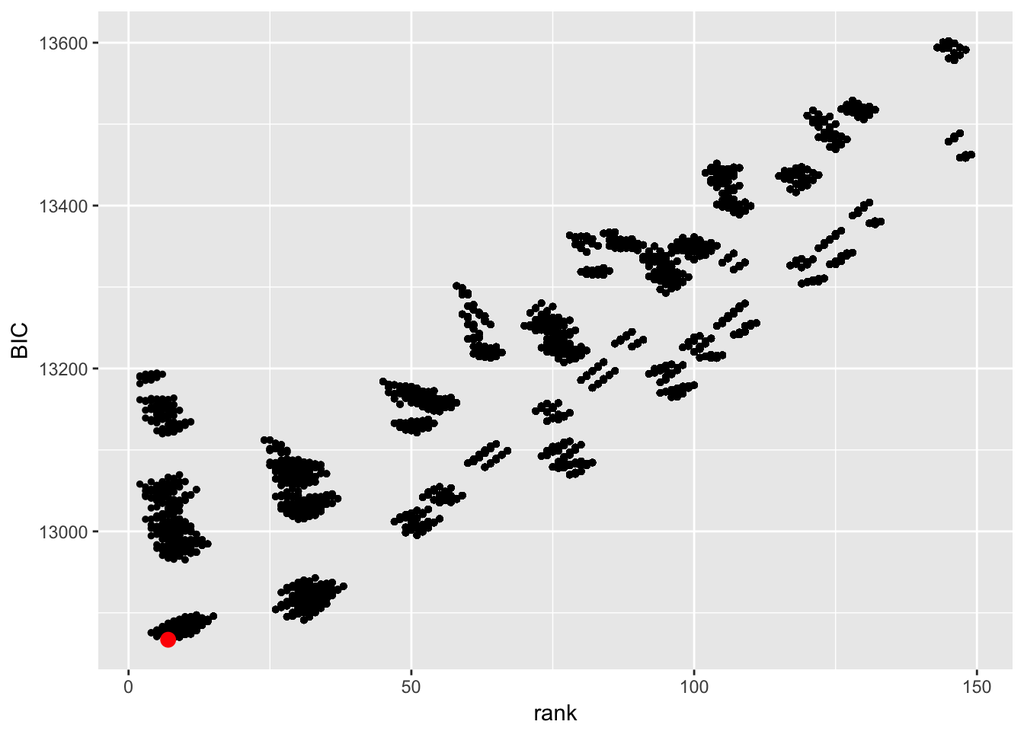

```r
library(ggplot2)
params <- as.data.frame(params)
colnames(params) <- c("BIC", "rank", "adjR2", "AIC")
ggplot(params, aes(rank, BIC)) +
  geom_point(size=1) +
  geom_point(data=params[which.min(params$BIC),], color="red", size=3)
```

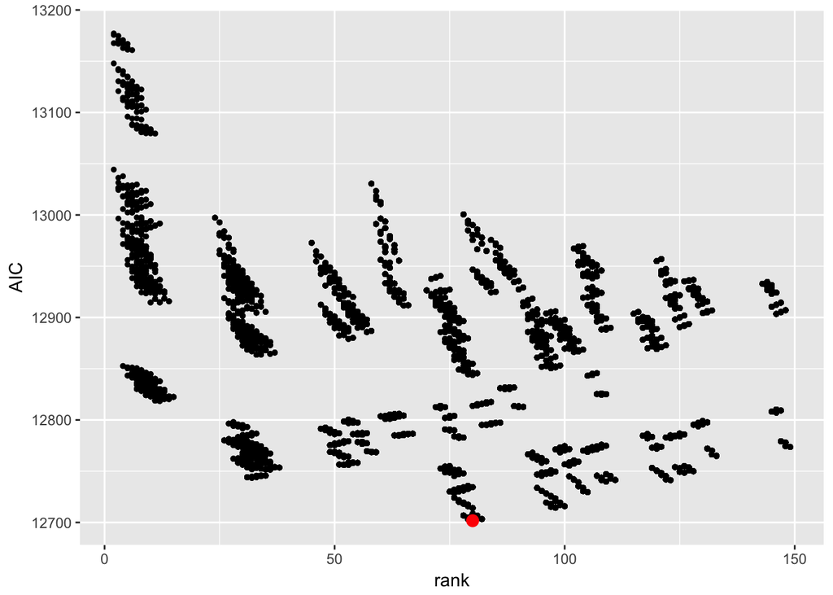

```r
ggplot(params, aes(rank, AIC)) +
  geom_point(size=1) +
  geom_point(data=params[which.min(params$AIC),], color="red", size=3)
```

## A teraz dane skorelowane

Rodowód BC i muszki owocowe.

```r
 attach(Drosophila)
 chr
```

```
##  [1] "X"    "X"    "X"    "X"    "X"    "X"    "chr1" "chr1" "chr1" "chr1"
## [11] "chr1" "chr1" "chr1" "chr1" "chr1" "chr1" "chr1" "chr1" "chr1" "chr2"
## [21] "chr2" "chr2" "chr2" "chr2" "chr2" "chr2" "chr2" "chr2" "chr2" "chr2"
## [31] "chr2" "chr2" "chr2" "chr2" "chr2" "chr2" "chr2" "chr2" "chr2" "chr2"
## [41] "chr2"
```

```r
 pos
```

```
##  [1]   0.00   3.60  14.20  23.40  40.60  59.30   0.00   6.98  17.08  22.02
## [11]  28.53  34.72  67.96  71.86  76.41 113.92 135.11 138.82 145.85   0.00
## [21]   4.99  14.33  21.30  28.74  49.99  53.54  59.86  71.72  76.30  83.15
## [31]  89.50 101.29 114.17 123.32 126.62 134.60 147.69 157.73 161.43 171.22
## [41] 174.65
```

```r
 head(bs)
```

```
##        ewg w rp v sd run gl pgk cg gpdh ninaC glt mhc ddc duc sli egfr twi
## BS01-1   0 0  0 0  0   0  1   0  0    0     0   0   1   1   1   1    1   1
## BS01-2   2 2  2 2  2   2  1   1  1    1     1   1   1   1   0   1    1   1
## BS01-3   0 0  0 0  0   0  1   1  1    1     1   1   1   1   1   1    0   0
## BS01-4   2 2  2 2  0   0  0   0  0    0     0   0   1   1   1   1    1   1
## BS01-5   0 0  0 0  0   0  0   0  0    0     0   0   0   0   0   0    1   1
## BS02-1   0 2  2 2  2   2  1   1  1    1     1   1   1   1   1   0    0   0
##        zip lsp ve acr dbi h fz eip tra rdg ht ant ninaE fas mst odh tub hb
## BS01-1   1   0  1   1   1 1  1   1   1   0  0   0     0   0   0   0   0  1
## BS01-2   1   0  0   0   0 0  0   0   0   0  1   1     1   1   1   1   1  0
## BS01-3   0   0  0   0   1 1  1   0   1   1  0   0     0   0   0   0   0  0
## BS01-4   1   1  1   1   1 1  1   1   1   1  1   1     1   1   1   0   0  0
## BS01-5   1   1  1   1   1 0  0   0   0   0  0   0     0   0   0   0   0  1
## BS02-1   0   1  1   1   0 0  0   0   0   0  0   0     0   0   0   0   0  0
##        rox ald mlc jan efi     pc1  adjpc1    area   areat tibia
## BS01-1   1   1   1   1   1 0.00984 0.10939 0.00787 0.01887 0.417
## BS01-2   0   0   0   0   1 0.01268 0.14151 0.00816 0.01860 0.439
## BS01-3   1   1   1   1   1 0.01033 0.12961 0.00805 0.01851 0.435
## BS01-4   0   0   0   0   0 0.00417 0.13079 0.00639 0.01449 0.441
## BS01-5   1   1   1   1   1 0.01848 0.16576 0.00977 0.02388 0.409
## BS02-1   0   0   0   0   0 0.01610 0.17826 0.00884 0.02051 0.431
```

```r
 korr = cor(model.matrix(pc1~., data=bs[,1:42])[,-1])
 korr[1:6,1:6]
```

[output not shown]

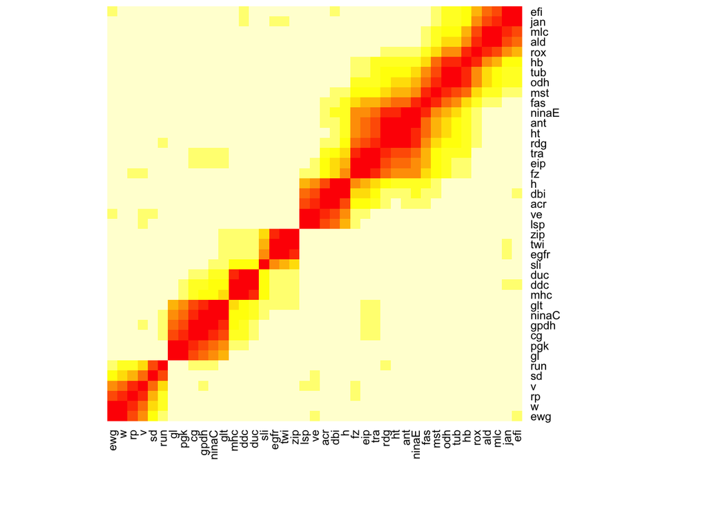

```r
 heatmap(1-abs(korr),symm=T,Rowv=NA,Colv=NA)
```

```r
 # współczynnik współliniowości kolumn
 library(car)
 vif(lm(pc1~., data=(dat<-bs[,1:42])))
```

```
##       ewg         w        rp         v        sd       run        gl
##  7.690664  9.137029  4.800058  4.202430  2.917888  2.141868  4.794329
##       pgk        cg      gpdh     ninaC       glt       mhc       ddc
##  6.284281 10.253837 12.402848  9.290877  6.062582  6.698641 10.295207
##       duc       sli      egfr       twi       zip       lsp        ve
##  4.900250  1.695382  7.369367 10.980767  4.962627  6.144002  8.744777
##       acr       dbi         h        fz       eip       tra       rdg
##  8.272664  8.539726  4.253744  8.014706 11.055961  6.976073  9.046203
##        ht       ant     ninaE       fas       mst       odh       tub
## 11.227116 10.836373  7.225617  4.983311  4.810534 10.007537  9.854711
##        hb       rox       ald       mlc       jan       efi
##  5.529557  4.549265  8.740273  8.656464 11.685838  9.664005
```

Model jednowymiarowy

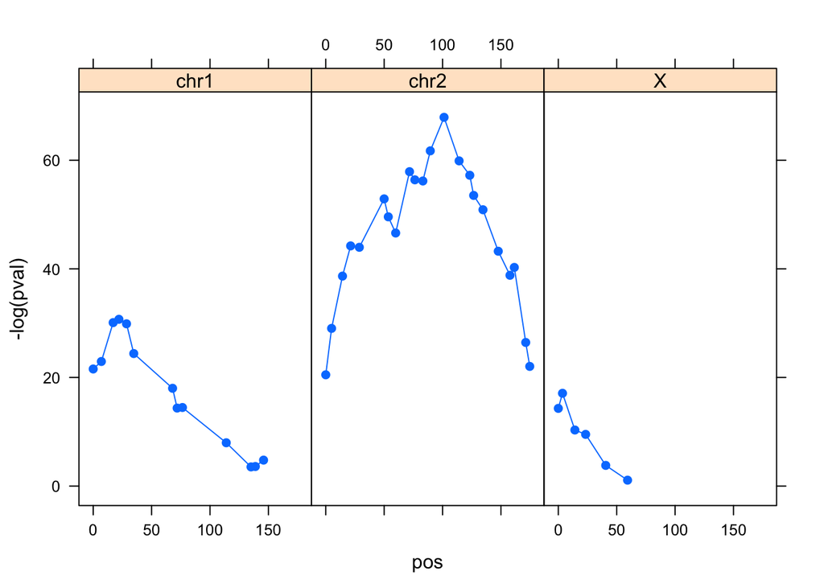

```r
 library(lattice)
 pval = numeric(41)
 for (i in 1:41) {
     pval[i] = summary(aov(bs$pc1 ~ bs[,i]))[[1]][1,5]
 }
 xyplot(-log(pval)~pos|chr, type=c("p","l"), pch=19)
```

Model dwuwymiarowy

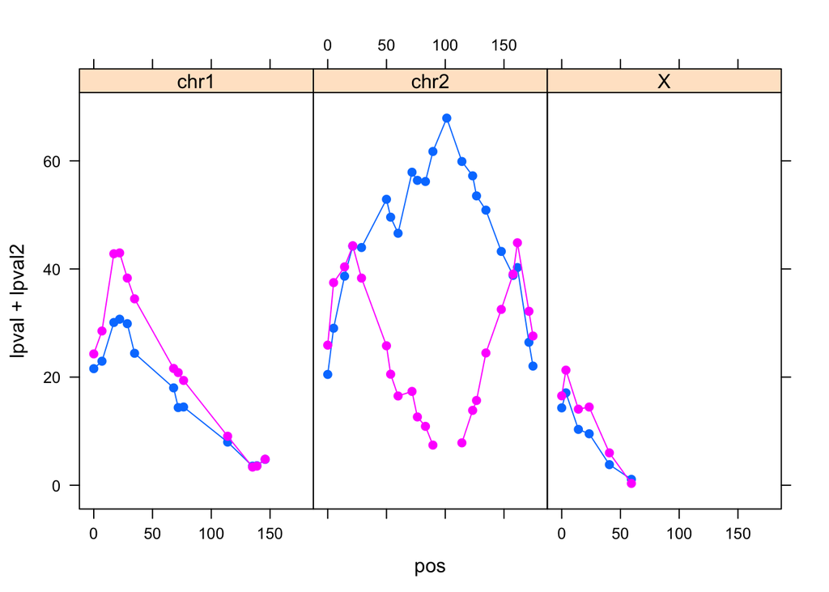

```r
 library(lattice)
 pval2 = numeric(41)
 for (i in 1:41) {
     pval2[i] = summary(aov(bs$pc1 ~ bs$fas + bs[,i]))[[1]][2,5]
 }
 lpval <- -log(pval)
 lpval2 <- -log(pval2)
 xyplot(lpval + lpval2~pos|chr, type=c("p","l"), pch=19)
```

## Opanujmy funkcję trace

Zaczynając od 1 do pełnego i od pełnego do 1.

```r
tmpFun = function(fit, aic) {
     list(size = length(fit$coefficients), aic = aic, likelihood = logLik(fit))
}

 model1 = step(lm(pc1~., data=bs[,1:42]), k=6, keep=tmpFun, trace=0)

 kolumny = colnames(bs)[1:41]
 maxModel = as.formula(paste("~",paste(kolumny,collapse="+")))

 # od modelu pustego do optymalnego
 model2 = step(lm(pc1~1, data=bs[,1:42]), scope=list(upper = maxModel, lower = ~1), direction ="forward", k=6, keep=tmpFun, trace=0)

 # od wybranego modelu do optymalnego
 model4 = step(lm(pc1~w+fas+gpdh, data=bs[,1:42]), scope=list(upper = maxModel, lower = ~1), k=6, keep=tmpFun, trace=0)

model4$keep
```

```
##            [,1]      [,2]      [,3]      [,4]      [,5]      [,6]
## size       4         5         6         7         8         9
## aic        -4193.984 -4300.863 -4442.334 -4522.696 -4570.619 -4609.404
## likelihood 1538.579  1595.018  1668.754  1711.935  1738.896  1761.288
##            [,7]      [,8]      [,9]      [,10]     [,11]     [,12]
## size       10        11        12        13        14        15
## aic        -4650.259 -4680.123 -4701.892 -4720.015 -4735.354 -4750.579
## likelihood 1784.716  1802.648  1816.533  1828.594  1839.264  1849.876
##            [,13]     [,14]     [,15]     [,16]
## size       16        17        18        19
## aic        -4760.037 -4765.404 -4768.103 -4770.44
## likelihood 1857.605  1863.289  1867.638  1871.807
```

Rysujemy te ścieżki

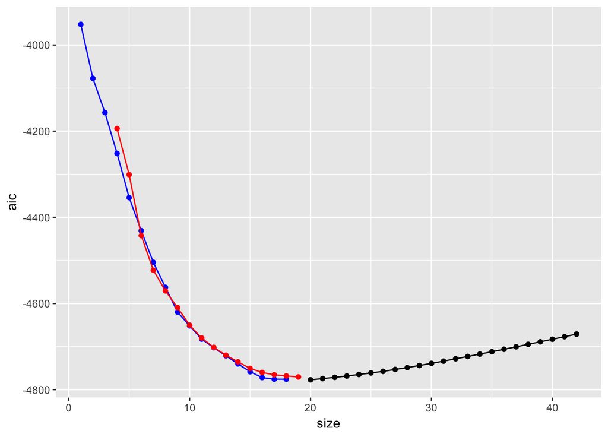

```r
getMD <- function(md) {
  data.frame(size = unlist(apply(md, 2, `[`, 1)),
             aic = unlist(apply(md, 2, `[`, 2)))
}

df1 <- getMD(model1$keep)
df2 <- getMD(model2$keep)
df4 <- getMD(model4$keep)

pl <- ggplot() +
  geom_point(data=df1, aes(size, aic)) +
  geom_line(data=df1, aes(size, aic)) +
  geom_point(data=df2, aes(size, aic), color="blue") +
  geom_line(data=df2, aes(size, aic), color="blue") +
  geom_point(data=df4, aes(size, aic), color="red")  +
  geom_line(data=df4, aes(size, aic), color="red")

pl
```

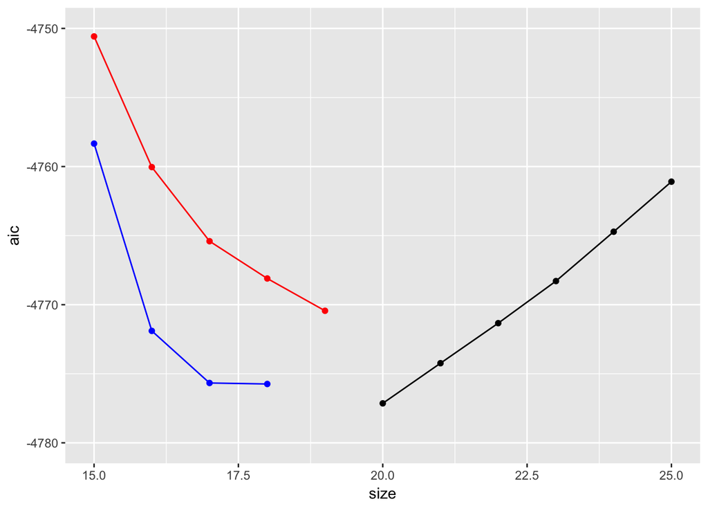

```r
pl + xlim(15,25) + ylim(-4780, -4750)
```

## Praca domowa

Z pakietu `PogromcyDanych` wybierz ze zbioru `auta2012` auta jednej marki. Zbuduj model statystyczny opisujący średnią cenę aut tej marki.

Uwzględnij przynajmniej 4 sensowe cechy i uzasadnij, że wybrany model jest dobry.